# TP4 Statistiques descriptives

Louai KASSA BAGHDOUCHE

28/11/2020

# 1. PARTIE 1: Calcul de probabilités

#### a. calcul de la probabilité qu’une variable aléatoire X suivant une loi binomiale de paramètres n=10 et p=1/3, B(10,1/3), soit égale à 1 ?

```r
prob <- dbinom(1, 10, 1/3); prob
```

```
## [1] 0.08670765
```

#### b. calcul de la probabilité qu’une variable aléatoire X suivant une loi B(10,1/3) soit égale à 0,1,2,…10

```r
for (i in 0:10) {
    print(dbinom(i, 10, 1/3))
}
```

```
## [1] 0.01734153
## [1] 0.08670765
## [1] 0.1950922
## [1] 0.2601229
## [1] 0.2276076
## [1] 0.1365645
## [1] 0.0569019
## [1] 0.01625768
## [1] 0.003048316
## [1] 0.0003387018
## [1] 1.693509e-05
```

#### c. calcul de la probabilité qu’une variable aléatoire X suivant une loi B(10,1/3) soit inférieure ou égale à 0,1,2,…10

```r
for (i in 0:10) {
    print(pbinom(i, 10, 1/3))
}
```

```
## [1] 0.01734153
## [1] 0.1040492
## [1] 0.2991414
## [1] 0.5592643
## [1] 0.7868719
## [1] 0.9234365
## [1] 0.9803384
## [1] 0.996596
## [1] 0.9996444
## [1] 0.9999831
## [1] 1
```

#### d. calcul de la probabilité qu’une variable aléatoire X suivant une loi B(10,1/3) soit supérieure à 5

```r
p <- 1 - pbinom(5, 10, 1/3); p
```

```
## [1] 0.07656353
```

#### e. calcul de la probabilité qu’une variable aléatoire X suivant une loi de Poisson P(2.5) soit égale à 0,1,2,…8 ?

```r
for (i in 0:8) {
    print(dpois(i, 2.5))
}
```

```
## [1] 0.082085
## [1] 0.2052125
## [1] 0.2565156
## [1] 0.213763
## [1] 0.1336019
## [1] 0.06680094
## [1] 0.02783373
## [1] 0.009940617
## [1] 0.003106443
```

```r
for (i in 0:8) {
    print(ppois(i, 2,5))
}
```

```
## [1] 0.1353353
## [1] 0.4060058
## [1] 0.6766764
## [1] 0.8571235
## [1] 0.947347
## [1] 0.9834364
## [1] 0.9954662
## [1] 0.9989033
## [1] 0.9997626
```

#### g. calcul de la probabilité qu’une variable aléatoire X suivant une loi de Poisson P(2.5) soit supérieure à 20

```r
ppois <- 1 - ppois(20, 2.5); ppois
```

```
## [1] 4.118927e-13
```

# 2. PARTIE 2: Les quantiles

#### a. calculer la valeur x, de la loi normale centrée réduite telle que P(X<=x) = 0.97

```r
xval <- qnorm(0.97, 0, 1); xval
```

```
## [1] 1.880794
```

#### b. calcul du quantile 2% pour une loi T de student à 5 ddl

```r
q <- qt(0.02, 5); q
```

```
## [1] -2.756509
```

#### c. calcul des quantiles de la colonne taille du data frame IMC, les comparer aux quantiles théoriques obtenus pour une loi normale

```r
tab <- read.table(file.choose(), header=TRUE, sep='\t', dec=',')
quantile(tab$taille)
```

```
##      0%     25%     50%     75%    100%
##  88.500  98.000 101.000 103.625 111.500
```

```r
quantile(rnorm(length(tab$taille), mean(tab$taille), sd(tab$taille)))
```

```
##        0%       25%       50%       75%      100%
##  90.29030  98.29459 101.71362 104.20643 110.88629
```

# 3. PARTIE 3: Catalogue de lois

#### a. recopier le code ci-dessous, essayer de faire varier les différents paramètres de façon à bien comprendre leurs effets

*la loi binomiale*

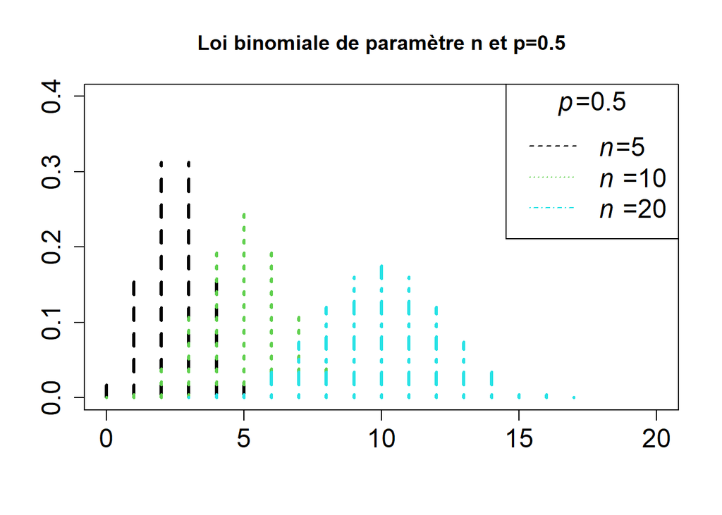

```r
x=0:5;n=5;
plot(x,dbinom(x,n,0.5),xlim=c(0,20),ylim=c(0,.40),type="h",lty=2,pch=n,cex=1,lwd=3,col=1,cex.axis=1.5,xlab="",ylab="");
x=0:10;n=10;
points(x,dbinom(x,n,0.5),type="h",pch=n,lty=3,cex=1,lwd=3,col=3)
x=0:20;n=20;
points(x,dbinom(x,n,0.5),type="h",lty=4,pch=n,cex=1,lwd=3,col=5)
legtxt=c(expression(paste(italic(n),"=5")), expression(paste(italic(n)," =10")), expression(paste(italic(n)," =20")) )
legend("topright",legtxt,title=expression(paste(italic(p),"=0.5")), lty=c(2,3,4),col=c(1,3,5),cex=1.5,bg="white")
title("Loi binomiale de paramètre n et p=0.5")
```

*la loi uniforme*

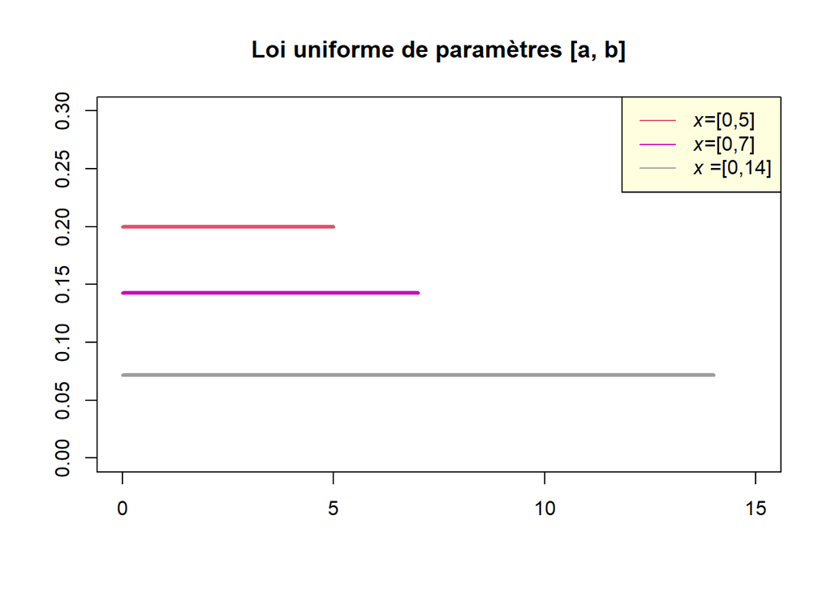

```r
x=0:5;
plot(x,dunif(x,0,5),xlim=c(0,15),ylim=c(0,0.3),type="l",lty=1,pch=0,cex=1,lwd=3,col=34,cex.axis=1,xlab="",ylab="");
x=0:7;
points(x,dunif(x, 0, 7),type="l",lty=1,pch=n,cex=1,lwd=3,col=14)
x=0:14;
points(x,dunif(x,0, 14),type="l",lty=1,pch=n,cex=1,lwd=3,col=24)

legtxt=c(expression(paste(italic(x),"=[0,5]")),
         expression(paste(italic(x),"=[0,7]")),
         expression(paste(italic(x)," =[0,14]")) )
legend("topright",legtxt, lty=c(1,1,1),col=c(34,14,24),cex=1,bg="lightyellow")
title("Loi uniforme de paramètres [a, b]")
```

*la loi de Bernoulli*

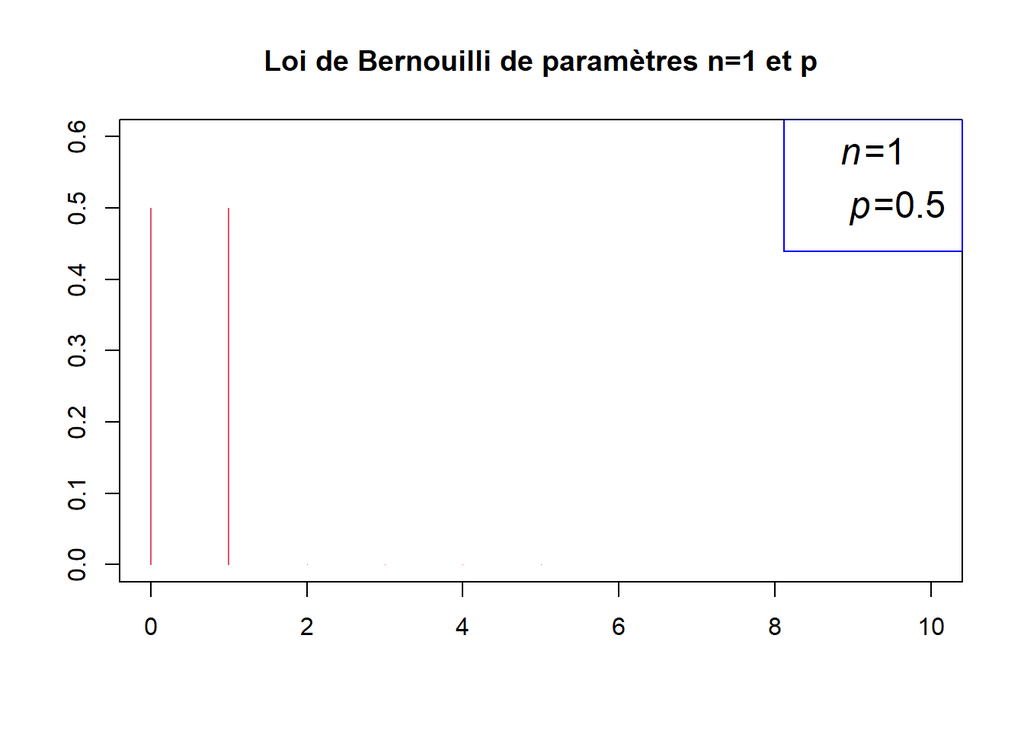

```r
x=0:5;n=1;p=0.5
plot(x,dbinom(x,n,0.5),xlim=c(0,10),ylim=c(0,0.6),type="h",col=2,xlab="",ylab="");


legtxt=c(expression(paste(italic(p),"=0.5")))

legend("topright",legtxt,title=expression(paste(italic(n),"=1")),col=c(2),cex=1.5, box.col="blue")
title("Loi de Bernouilli de paramètres n=1 et p")
```

*la loi de poisson*

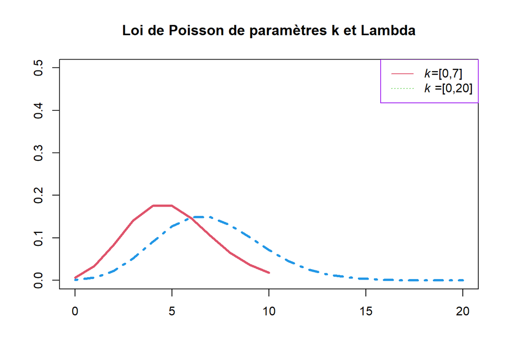

```r
k=0:10;
plot(k,dpois(k,lambda = 5), xlim = c(0,20), ylim =c(0,0.5),type="l",lty=1,pch=n,lwd=3,col=2,cex.axis=1,xlab="",ylab="");

k=0:20;
points(k,dpois(k,lambda = 7),type="l",lty=4,pch=n,lwd=3,col=4,cex.axis=1,xlab="",ylab="");

legtxt=c(expression(paste(italic(k),"=[0,7]")), expression(paste(italic(k)," =[0,20]")) )
legend("topright",legtxt, lty=c(1,3,4),col=c(2,3,4),cex=1, box.col = "purple")
title("Loi de Poisson de paramètres k et Lambda")
```

*la loi géométrique*

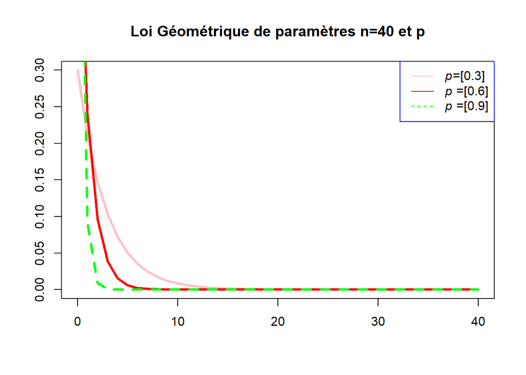

```r
x=seq(0, 40)
p = 0.3
plot(x,dgeom(x,p),type="l",lty=1,pch=n,lwd=3,col="pink",cex.axis=1,xlab="",ylab="")

p = 0.6
points(x,dgeom(x,p),type="l",lty=1,pch=n,lwd=3,col="red",cex.axis=1)

p = 0.9
points(x,dgeom(x,p),type="l",lty=2,pch=n,lwd=3,col="green",cex.axis=1)

legtxt=c(expression(paste(italic(p),"=[0.3]")),
         expression(paste(italic(p)," =[0.6]")),
         expression(paste(italic(p)," =[0.9]")) )
legend("topright",legtxt, lty=c(1,1,2),col=c("pink","red","green"),cex=1, box.col = "blue")
title("Loi Géométrique de paramètres n=40 et p")
```

*la loi hypergéométrique*

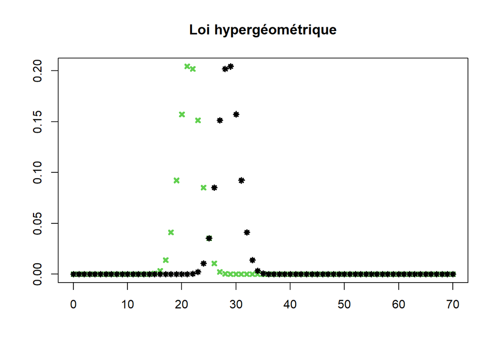

```r
x=0:70
plot(x,dhyper(x,m=50, n=20,k=30),type="p",pch=4,lwd=3,col="3",cex=0.7,cex.axis=1,xlab="",ylab="")

x=0:70
points(x,dhyper(x,m=50, n=20,k=40),type="p",pch=8,lwd=2,col="1",cex=0.7,cex.axis=1)

title("Loi hypergéométrique")
```

*la loi binomiale négative*

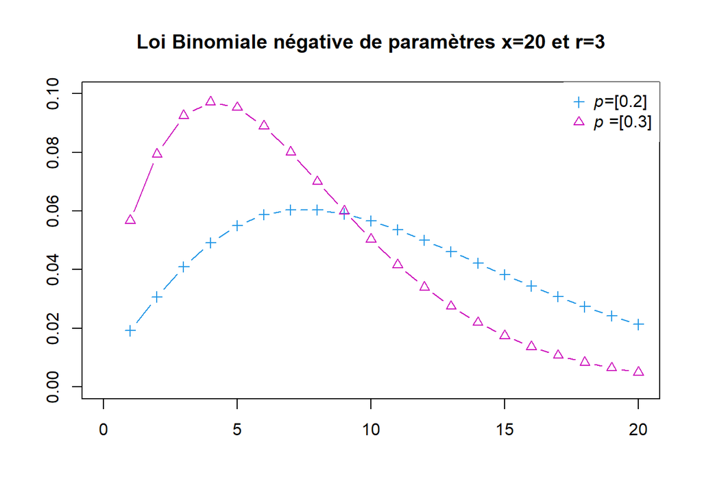

```r
r = 3 #taille (cible nombre essais réussis)
p = 0.20 #probabilité
x = 1:20 #vecteurs de quantiles
plot(x,dnbinom(x,r, prob = p),xlim=c(0,20), ylim=c(0,0.1),type="b",pch=3, col=4, xlab="", ylab="")
p=0.30
points(x,dnbinom(x,r,p),type='b', pch=2, col=6)

legtxt=c(expression(paste(italic(p),"=[0.2]")), expression(paste(italic(p)," =[0.3]")))
legend("topright",legtxt, pch=c(3,2),col=c(4,6),cex=1, box.col = "transparent")
title("Loi Binomiale négative de paramètres x=20 et r=3")
```

#### b.Même travail pour les lois continues classiques, sur le modèle ci-dessous : Loi Normale

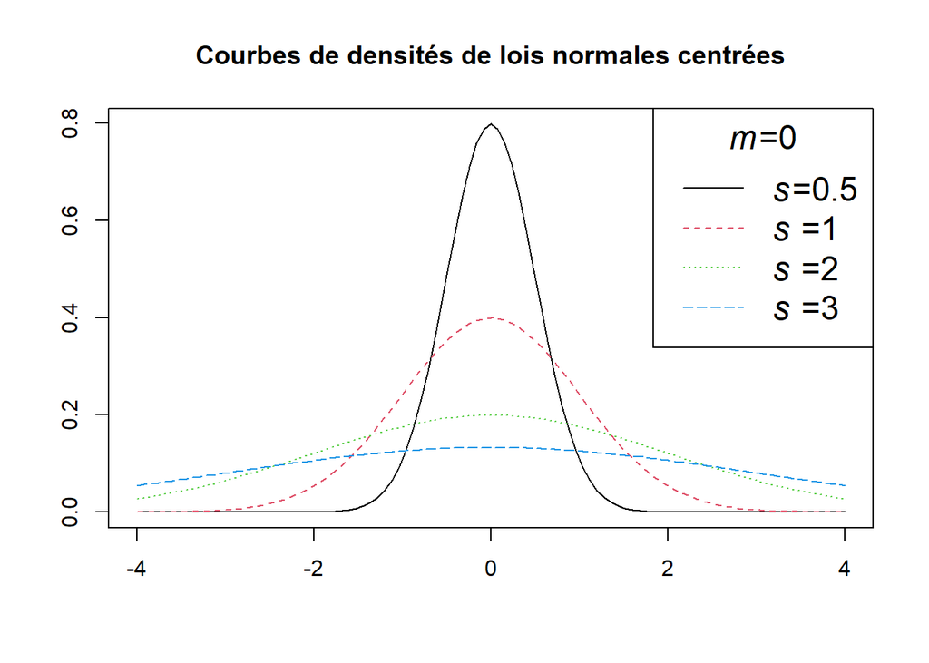

```r
curve(dnorm(x,0,0.5),from=-4,to=4,col=1,lty=1,xlab="",ylab="");
curve(dnorm(x,0,1),from=-4,to=4,col=2,add=TRUE,lty=2,xlab="",ylab="")
curve(dnorm(x,0,2),from=-4,to=4,col=3,add=TRUE,lty=3,xlab="",ylab="")
curve(dnorm(x,0,3),from=-4,to=4,col=4,add=TRUE,lty=5,xlab="",ylab="")
legtxt=c(expression(paste(italic(s),"=0.5")),
         expression(paste(italic(s)," =1")),
         expression(paste(italic(s)," =2")),
         expression(paste(italic(s)," =3"))) ;

legend("topright",legtxt,title=expression(paste(italic(m),"=0")), lty=c(1,2,3,5),col=c(1,2,3,4),cex=1.5,bg="white") ;
title("Courbes de densités de lois normales centrées")
```

Loi Exponentielle

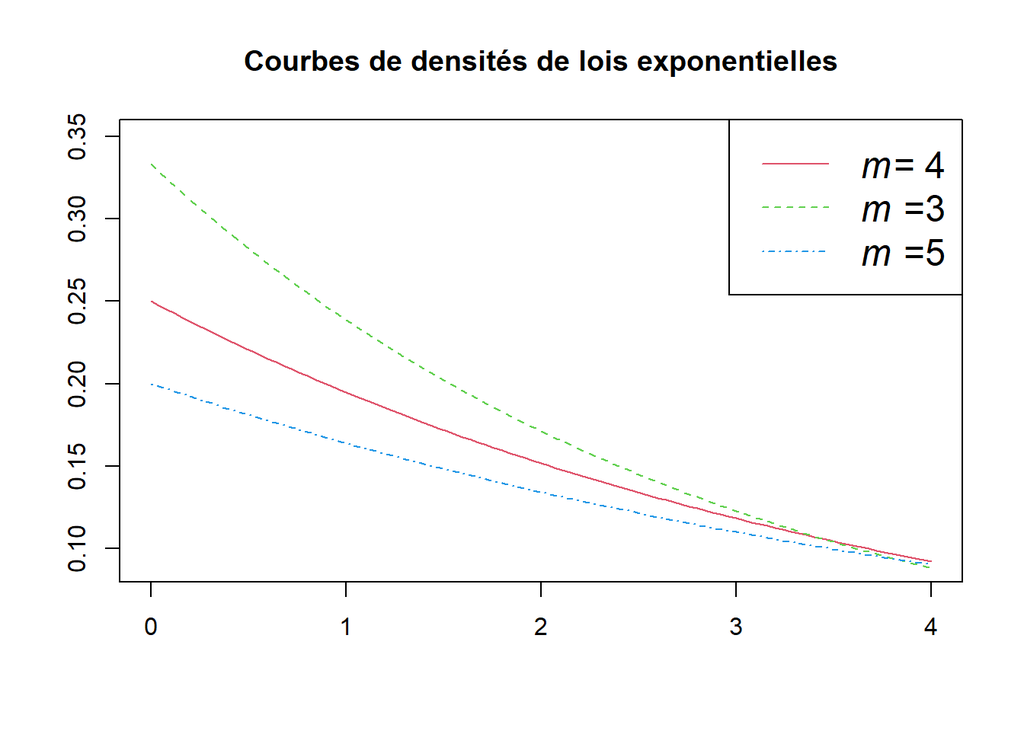

```r
#Exp(λ)
#λ=1/E(x);E(x)=moyenne(x)
m=4
curve(dexp(x,1/m),xlim=c(0,4), ylim=c(0.09,0.35),from=0,to=4,col=2,lty=1,xlab="",ylab="");
m=3
curve(dexp(x,1/m),col=3,add=TRUE,lty=2,xlab="",ylab="");
m=5
curve(dexp(x,1/m),col=4,add=TRUE,lty=4,xlab="",ylab="");

legtxt=c(expression(paste(italic(m),"= 4")),
         expression(paste(italic(m)," =3")),
         expression(paste(italic(m)," =5")));

legend("topright",legtxt, lty=c(1,2,4),col=c(2,3,4),cex=1.5)
title("Courbes de densités de lois exponentielles")
```

La loi uniforme continu

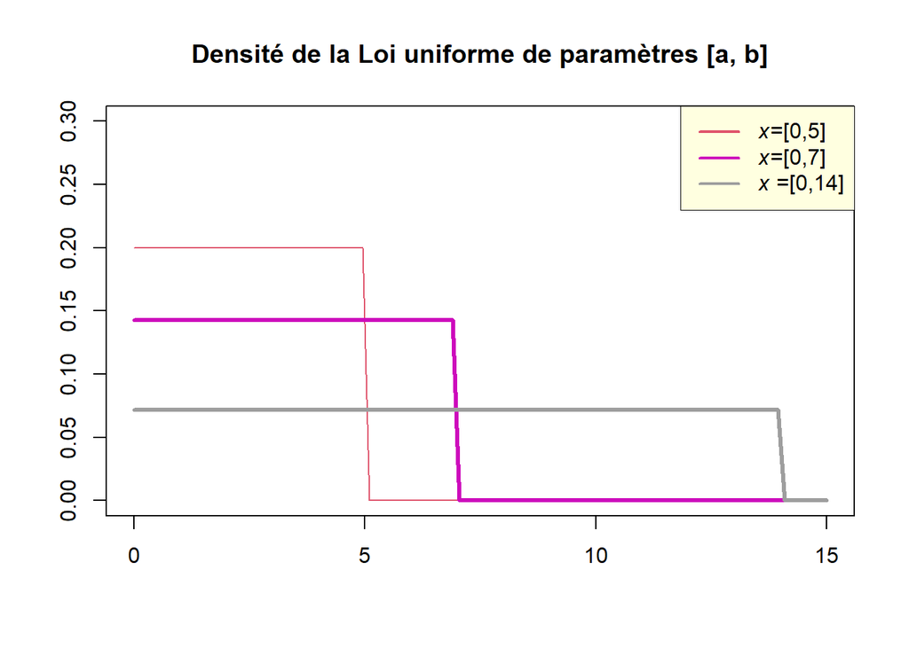

```r
x=0:5;
curve(dunif(x,0,5),xlim=c(0,15),ylim=c(0,0.3),lty=1,pch=0,cex=1,col=34,xlab="",ylab="");
x=0:7;
curve(dunif(x, 0, 7),lty=1,pch=n,cex=1,lwd=3,col=14, add=TRUE)
x=0:14;
curve(dunif(x,0, 14),type="l",lty=1,pch=n,cex=1,lwd=3,col=24, add=TRUE)

legtxt=c(expression(paste(italic(x),"=[0,5]")),
         expression(paste(italic(x),"=[0,7]")),
         expression(paste(italic(x)," =[0,14]")) )
legend("topright",legtxt, lty=c(1,1,1),col=c(34,14,24),lwd=c(2),cex=1,bg="lightyellow",box.lwd=0.5)
title("Densité de la Loi uniforme de paramètres [a, b]")
```

La loi du student

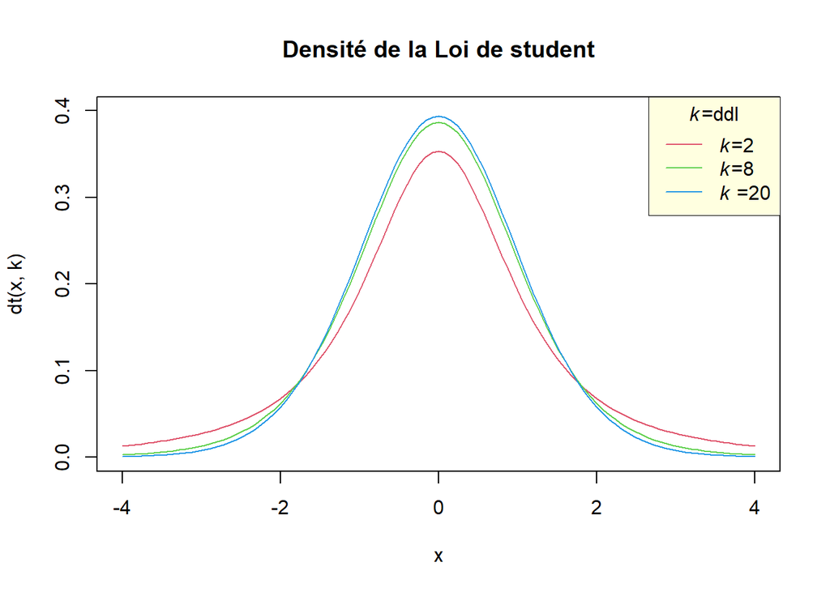

```r
#T(k) où k est le degrès de liberté = ddl
k=2
curve(dt(x, k),xlim=c(-4,4),ylim=c(0,0.4),col=2)
k=8
curve(dt(x, k),add=TRUE, col=3)
k=20
curve(dt(x, k),add=TRUE, col=4)

legtxt=c(expression(paste(italic(k),"=2")),
         expression(paste(italic(k),"=8")),
         expression(paste(italic(k)," =20")) )
legend("topright",legtxt,title=expression(paste(italic(k),"=ddl")),lty=c(1,1,1),
       col=c(2,3,4),cex=1,bg="lightyellow",box.lwd=0.5);
title("Densité de la Loi de student")
```

La loi de chi2

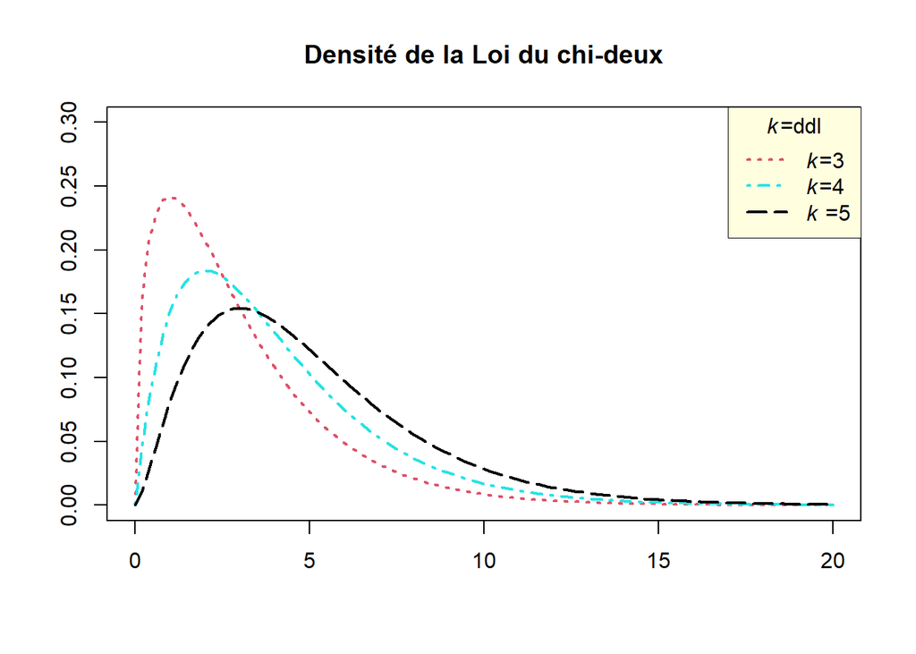

```r
#χ2(k)
k=3
curve(dchisq(x, k),xlim=c(0,20),ylim=c(0,0.3),lty=3,col=2,lwd=2, xlab="", ylab="")
k=4
curve(dchisq(x, k),lty=4,col=5,lwd=2,add=TRUE)
k=5
curve(dchisq(x, k),lty=5,col=9,lwd=2, add=TRUE)

legtxt=c(expression(paste(italic(k),"=3")),
         expression(paste(italic(k),"=4")),
         expression(paste(italic(k)," =5")) )
legend("topright",legtxt,title=expression(paste(italic(k),"=ddl")),
       lty=c(3,4,5),col=c(2,5,9),lwd=c(2),cex=1,bg="lightyellow",box.lwd=0.5);
title("Densité de la Loi du chi-deux")
```

La loi logistique

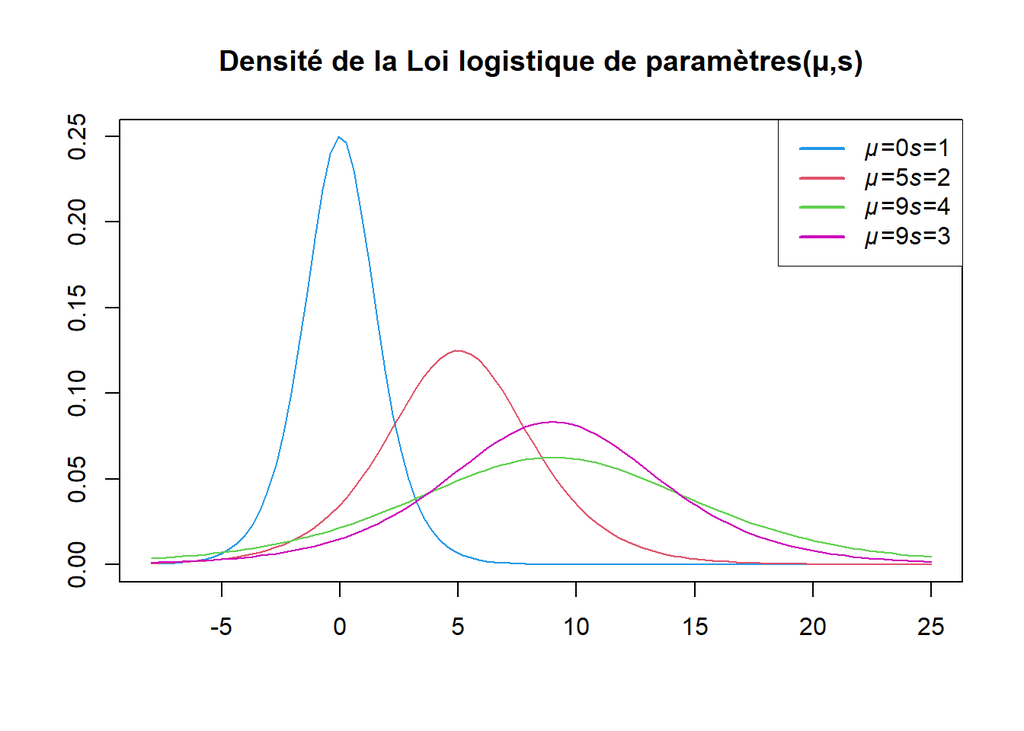

```r
curve(dlogis(x, location = 0, scale = 1, log = FALSE),xlim=c(-8,25), xlab="", ylab="",col=4)
curve(dlogis(x, location = 5, scale = 2, log = FALSE),col=2,add=TRUE)
curve(dlogis(x, location = 9, scale = 4, log = FALSE),col=3,add=TRUE)
curve(dlogis(x, location = 9, scale = 3, log = FALSE),col=6,add=TRUE)

legtxt=c(expression(paste(italic(µ),"=0","\n",italic(s),"=1")),
         expression(paste(italic(µ),"=5","\n",italic(s),"=2")),
         expression(paste(italic(µ),"=9","\n",italic(s),"=4")),
         expression(paste(italic(µ),"=9","\n",italic(s),"=3")))

legend("topright",legtxt,
       ,col=c(4,2,3,6),lwd=c(2),cex=1,box.lwd=0.5);
title("Densité de la Loi logistique de paramètres(µ,s)")
```

La loi de fisher

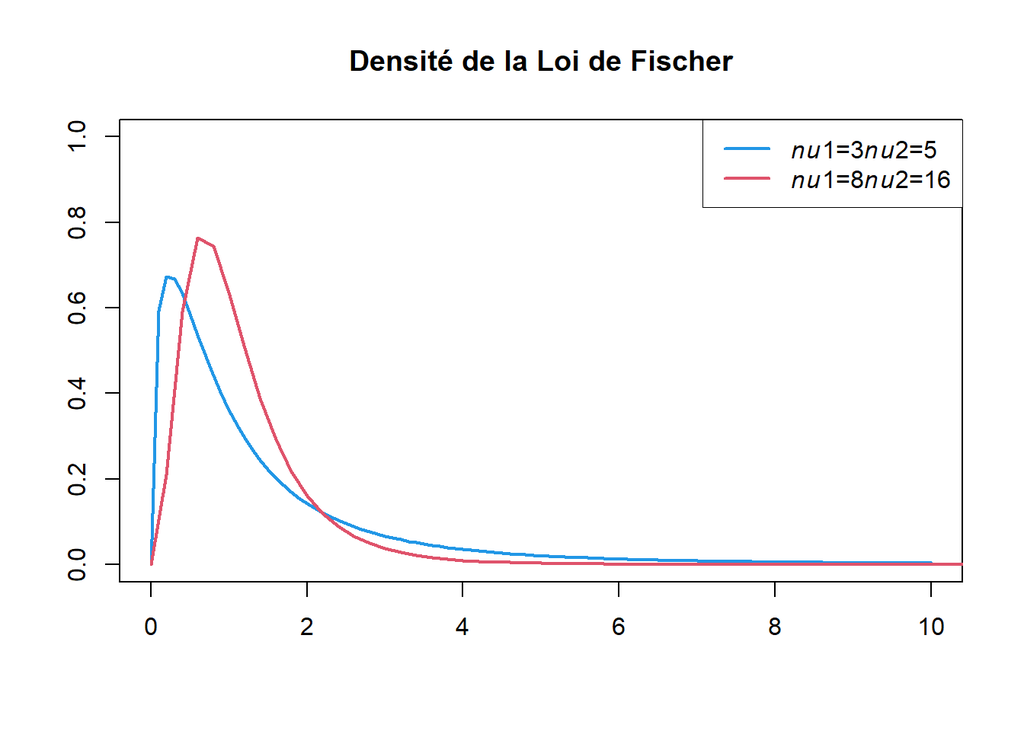

```r
#F(d1,d2) où d est le dégrès de liberté
nu1=3
nu2=5
curve(df(x,nu1, nu2),xlim=c(0,10),ylim=c(0,1),col=4,lwd=2, xlab="", ylab="")
nu1=8
nu2=16
curve(df(x,nu1, nu2),xlim=c(0,20),ylim=c(0,0.7),col=2,lwd=2, add=TRUE)
legtxt=c(expression(paste(italic(nu1),"=3","\n",italic(nu2),"=5")),
         expression(paste(italic(nu1),"=8","\n",italic(nu2),"=16")))

legend("topright",legtxt,
       ,col=c(4,2),lwd=c(2),cex=1,box.lwd=0.5);
title("Densité de la Loi de Fischer")
```